# COVID-19 LCA clustering

Cristina Muntañola

2022-11-04

## Load packages

```r
# install.packages(c('tidyverse', 'lubridate', 'forcats', 'haven', 'here', 'readr', 'data.table', 'unpivotr', 'naniar', 'skimr', 'dplyr', 'rstatix', 'janitor', 'readxl', 'poLCA', 'furniture', 'sjlabelled', 'flextable', 'reshape', 'foreign', 'epiR'), method = 'wininet', repos = 'https://cran.r-project.org')

library(tidyverse)
library(lubridate)
library(forcats)
library(haven)
library(here)
library(readr)
library(data.table)
library(unpivotr)
library(naniar)
library(skimr)
library(dplyr)
library(rstatix)
library(janitor)
library(readxl)
library(poLCA)
library(furniture)
library(sjlabelled)
library(flextable)
library(reshape)
library(foreign)
library(epiR)
```

# LCA common syntax

## Before anything

First of all, you must run the scripts to create your databases. The **poblacion** database contains the following columns: the CIPA (or identifier) for each individual, date of birth, sex, and country of origin.

The **entero** database contains the CIPA, variables identifying individuals with COVID-19 (laboratory tests, etc.), hospital admission, admission due to COVID-19, ICU admission, COVID-19 mortality, the chronic conditions, and the deprivation index, as well as sex and age (sourced from the poblacion database).

```r
cipas_coger=entero$cipa

stopifnot(length(cipas_coger)==312718) # Tiene que haber 312718
```

```r
entero$cipa=as.numeric(entero$cipa)

library(dplyr)

length(unique(entero$cipa))
```

```
## [1] 312718
```

```r
myMMsample=entero[as.numeric(entero$cipa) %in% cipas_coger,]

length(unique(myMMsample$cipa))
```

```
## [1] 312718
```

```r
poblacion=poblacion[poblacion$cipa %in% cipas_coger,]
```

Here, we calculate the individuals’ ages. We will use the individuals’ ages as of the middle of the year, corresponding to July 2nd. At this point, we could subset the dataset to select specific age groups.

```r
2020-65 # incluido 65 años
```

```
## [1] 1955
```

```r
poblacion$edad=floor(time_length(difftime(as.Date("2020-07-02"), as.Date(poblacion$fec_nacimiento_pob)), "years"))
```

```r
length(unique(poblacion$cipa))
```

```
## [1] 312718
```

```r
# poblacion=poblacion[!is.na(poblacion$edad) & poblacion$edad >= 65 & (poblacion$cipa %in% cipas_coger), ]
poblacion=poblacion[!is.na(poblacion$edad) & (poblacion$cipa %in% cipas_coger), ]
nrow(poblacion)
```

```
## [1] 312718
```

```r
table(poblacion$edad)
```

```
##
##    0    1    2    3    4    5    6    7    8    9   10   11   12   13   14   15
##  855 1840 1554 1330 1251 1111 1015  937  889  864  880  904  900  849  819  874
##   16   17   18   19   20   21   22   23   24   25   26   27   28   29   30   31
##  949  998 1156 1417 1571 1896 2106 2613 2767 3162 3664 3990 4111 4163 4466 4568
##   32   33   34   35   36   37   38   39   40   41   42   43   44   45   46   47
## 4539 4938 4960 5460 5570 6036 6449 6656 7017 7188 7520 7663 7629 7666 7455 7246
##   48   49   50   51   52   53   54   55   56   57   58   59   60   61   62   63
## 7178 7007 6995 6834 6673 6621 6507 6613 6289 5959 5724 5408 5344 5189 4737 4173
##   64   65   66   67   68   69   70   71   72   73   74   75   76   77   78   79
## 3642 3242 2512 2336 2285 2228 2202 2253 2352 1896 1912 1851 1850 1705 1292 1372
##   80   81   82   83   84   85   86   87   88   89   90   91   92   93   94   95
## 1454 1056 1179 1268 1256 1170 1161 1118 1046  917  880  729  674  540  460  355
##   96   97   98   99  100  101  102  103  104  105  106  109  110
##  261  194  132   89   61   32   16   13    7    5    1    1    1
```

```r
myMMsample=myMMsample[as.numeric(myMMsample$cipa) %in% poblacion$cipa, ]
nrow(myMMsample) # personas con COVID de mas de 65 años: 47.364. Cualquier edad: 51.334
```

```
## [1] 312718
```

```r
# myMMsample=myMMsample[!is.na(myMMsample$fech_nacimiento) & myMMsample$edad >= 65 & (myMMsample$Caso_con_prueba_positiva=='1' | myMMsample$Sospecha_con_prueba_positiva=='1' | myMMsample$Contacto_con_prueba_positiva=='1'), ]
```

In this case, I am going to remove the columns that do not relate to the conditions, since we want to perform the LCA; this leaves only the CIPA and the conditions.

```r
hosp_UCI_muert=myMMsample[,c("cipa", "num_ing", "UCI", "U071cualquierC", "U071_C1", "COVIDMortalidad")]
myMMsample=myMMsample[,append(TRUE, c(grepl('_comor$', colnames(myMMsample))[-1]))] # cojo solo enfermedades
```

The variables must be numeric.

```r
myMMsample[,2:ncol(myMMsample)] = apply(myMMsample[,2:ncol(myMMsample)], 2, function(x) as.numeric(x))
```

```r
memory.limit(size=1000000000000)
```

```
## [1] Inf
```

```r
myMMsample=distinct(myMMsample)
nrow(myMMsample)
```

```
## [1] 312718
```

I have now 312718 individuals. I’m going to remove the rows that have a 0 across the board for conditions, although they should already be filtered out.

```r
myMMsample=myMMsample[apply(myMMsample[,-1], 1, function(x) !all(x==0)),]
nrow(myMMsample)
```

```
## [1] 125061
```

```r
125061*100/312718
```

```
## [1] 39.99162
```

Now we have 125061 individuals.

Now I remove the rows that have only one disease (*TO RETAIN PEOPLE WITH MULTIMORBIDITY*).

```r
myMMsample=myMMsample[apply(myMMsample[,-1], 1, function(x) (sum(x)>1)),]
nrow(myMMsample)
```

```
## [1] 51835
```

```r
backup_myMMsample=myMMsample

51835*100/125061
```

```
## [1] 41.44777
```

```r
51835*100/312718
```

```
## [1] 16.57564
```

There are only 51.835 individuals.

```r
stopifnot(!any(rowSums(myMMsample[ ,2:ncol(myMMsample)])==0))
```

## Grouping of certain diseases

```r
myMMsample$NeoplasiasDigestivas=ifelse(myMMsample$D74_comor==1 | myMMsample$D76_comor==1 | myMMsample$D77_comor==1, 1, 0)


myMMsample$CardipatiasIsquemicas=ifelse(myMMsample$K74_comor==1 | myMMsample$K75_comor==1 | myMMsample$K76_comor==1, 1, 0)

myMMsample$EnfermedadesCerebrovascIctus=ifelse(myMMsample$K90_comor==1 | myMMsample$K91_comor==1, 1, 0)


myMMsample$ArtrosisVarias=ifelse(myMMsample$L89_comor==1 | myMMsample$L90_comor==1 | myMMsample$L91_comor==1, 1, 0)


myMMsample$NeoplasiasRespirat=ifelse(myMMsample$R84_comor==1 | myMMsample$R85_comor==1, 1, 0)


myMMsample$NeoplasiasAparatUrinario=ifelse(myMMsample$U75_comor==1 | myMMsample$U76_comor==1 | myMMsample$U77_comor==1, 1, 0)

myMMsample$NeoplasiasGenitalesFemeninas=ifelse(myMMsample$X75_comor==1 | myMMsample$X77_comor==1, 1, 0)
```

In a couple of chunks, we will remove the original ones, leaving only the grouped ones.

## Prevalence test for chronic diseases

```r
num_cols=nrow(myMMsample)



df <- data.frame(Positivos=numeric(),
                 Total_Casos=numeric(),
                 stringsAsFactors=FALSE)

for (num_col in 2:ncol(myMMsample)){
  a=sum(myMMsample[num_col])
  df[nrow(df) + 1,] = c(a, num_cols)

}
```

```r
rownames(df)=colnames(myMMsample)[-1]
```

```r
df$Prevalencia=NA

for (num_rows in 1:nrow(df)){
  b=round(epi.conf(as.matrix(df[num_rows,]), ctype = "prevalence", method = "exact", N = df[num_rows,2], design = 1, conf.level = 0.95) * 100, 2)
  df[num_rows,3] = b[1,1]
}
```

```r
df
```

|  | Positivos | Total_Casos | Prevalencia |
| --- | --- | --- | --- |
| A79_comor | 409 | 51835 | 0.79 |
| B74_comor | 224 | 51835 | 0.43 |
| D74_comor | 185 | 51835 | 0.36 |
| D75_comor | 2133 | 51835 | 4.11 |
| D76_comor | 99 | 51835 | 0.19 |
| D77_comor | 235 | 51835 | 0.45 |
| K71_comor | 908 | 51835 | 1.75 |
| K74_comor | 2818 | 51835 | 5.44 |
| K75_comor | 2774 | 51835 | 5.35 |
| K76_comor | 1201 | 51835 | 2.32 |

[output cut: 40 more lines]

```r
View(df)
```

I am removing the source diseases used to create the grouped columns.

```r
myMMsample$D74_comor=myMMsample$D76_comor=myMMsample$D77_comor=myMMsample$K74_comor=myMMsample$K75_comor=myMMsample$K76_comor=myMMsample$K90_comor=myMMsample$K91_comor=myMMsample$L89_comor=myMMsample$L90_comor=myMMsample$L91_comor=myMMsample$R84_comor=myMMsample$R85_comor=myMMsample$U75_comor=myMMsample$U76_comor=myMMsample$U77_comor=myMMsample$X75_comor=myMMsample$X77_comor=NULL
```

```r
num_cols=nrow(myMMsample)


df <- data.frame(Positivos=numeric(), # empty df
                 Total_Casos=numeric(),
                 stringsAsFactors=FALSE)

for (num_col in 2:ncol(myMMsample)){
  a=sum(myMMsample[num_col])
  df[nrow(df) + 1,] = c(a, num_cols)

}

rownames(df)=colnames(myMMsample)[-1]


df$Prevalencia=NA

for (num_rows in 1:nrow(df)){
  b=epi.conf(as.matrix(df[num_rows,]), ctype = "prevalence", method = "exact", N = df[num_rows,2], design = 1, conf.level = 0.95) * 100
  df[num_rows,3] = b[1,1] # value of the statistic
}
```

We now define a threshold above which we wish to select the diseases. Since this allows us to select diseases that are important for our case, we set the threshold at 1.5.

```r
# threeshold=2
threeshold=1.5


rownames(df)[df$Prevalencia >= threeshold]
```

```
##  [1] "D75_comor"                    "K71_comor"
##  [3] "K77_comor"                    "K78_comor"
##  [5] "K86_comor"                    "K87_comor"
##  [7] "K89_comor"                    "K93_comor"
##  [9] "L88_comor"                    "R95_comor"
## [11] "R96_comor"                    "S77_comor"
## [13] "T89_comor"                    "T90_comor"
## [15] "U99_comor"                    "U99.01_comor"
## [17] "X76_comor"                    "Y77_comor"
## [19] "CardipatiasIsquemicas"        "EnfermedadesCerebrovascIctus"
## [21] "ArtrosisVarias"               "NeoplasiasRespirat"
## [23] "NeoplasiasAparatUrinario"     "NeoplasiasGenitalesFemeninas"
```

```r
rownames(df)[df$Prevalencia >= 2]
```

```
##  [1] "D75_comor"                    "K77_comor"
##  [3] "K78_comor"                    "K86_comor"
##  [5] "K87_comor"                    "K89_comor"
##  [7] "K93_comor"                    "L88_comor"
##  [9] "R95_comor"                    "R96_comor"
## [11] "S77_comor"                    "T90_comor"
## [13] "U99_comor"                    "U99.01_comor"
## [15] "X76_comor"                    "Y77_comor"
## [17] "CardipatiasIsquemicas"        "EnfermedadesCerebrovascIctus"
## [19] "ArtrosisVarias"               "NeoplasiasRespirat"
## [21] "NeoplasiasAparatUrinario"     "NeoplasiasGenitalesFemeninas"
```

```r
prevalentes=which(df$Prevalencia >= threeshold)



prevalentes=append((prevalentes+1), c(1), 0)

rownames(df)[which(df$Prevalencia >= 5)] # example with prevalence higher than 5
```

```
##  [1] "K77_comor"                    "K78_comor"
##  [3] "K86_comor"                    "K87_comor"
##  [5] "K89_comor"                    "L88_comor"
##  [7] "R95_comor"                    "R96_comor"
##  [9] "S77_comor"                    "T90_comor"
## [11] "U99_comor"                    "U99.01_comor"
## [13] "CardipatiasIsquemicas"        "EnfermedadesCerebrovascIctus"
## [15] "ArtrosisVarias"
```

```r
MM.condition <- rownames(df)[which(df$Prevalencia >= threeshold)]
```

```r
head(myMMcondition <- myMMsample[, prevalentes],3)
```

|  | cipa | D75_comor | K71_comor | K77_comor | K78_comor | K86_comor | K87_comor | K89_comor | K93_comor | L88_comor | R95_comor | R96_comor | S77_comor | T89_comor | T90_comor | U99_comor | U99.01_comor | X76_comor | Y77_comor | CardipatiasIsquemicas | EnfermedadesCerebrovascIctus | ArtrosisVarias | NeoplasiasRespirat | NeoplasiasAparatUrinario | NeoplasiasGenitalesFemeninas |
| --- | --- | --- | --- | --- | --- | --- | --- | --- | --- | --- | --- | --- | --- | --- | --- | --- | --- | --- | --- | --- | --- | --- | --- | --- | --- |
| 4 | 1012352927 | 0 | 0 | 0 | 0 | 1 | 0 | 0 | 0 | 0 | 0 | 0 | 0 | 0 | 1 | 0 | 0 | 0 | 0 | 0 | 0 | 0 | 0 | 0 | 0 |
| 5 | 1012354846 | 0 | 0 | 0 | 0 | 0 | 0 | 0 | 0 | 0 | 0 | 0 | 0 | 0 | 0 | 0 | 0 | 0 | 0 | 0 | 0 | 1 | 0 | 0 | 0 |
| 8 | 1012359492 | 0 | 0 | 0 | 0 | 1 | 0 | 0 | 0 | 0 | 0 | 0 | 0 | 0 | 0 | 0 | 0 | 0 | 0 | 0 | 0 | 1 | 0 | 0 | 0 |

```r
colnames(myMMcondition)[2:ncol(myMMcondition)] =substr(colnames(myMMcondition),1,nchar(colnames(myMMcondition))-6)[2:ncol(myMMcondition)] # lo dejo en A79, D76...etc
```

Now I change and give some names to the grouped ones…..

```r
colnames(myMMcondition)[colnames(myMMcondition)=="CardipatiasIsqu"]='CR1'
colnames(myMMcondition)[colnames(myMMcondition)=="EnfermedadesCerebrovas"]='CR2'
colnames(myMMcondition)[colnames(myMMcondition)=="Artrosis"]='CR3'
colnames(myMMcondition)[colnames(myMMcondition)=="NeoplasiasRe"]='CR4'
colnames(myMMcondition)[colnames(myMMcondition)=="NeoplasiasAparatUr"]='CR5'
colnames(myMMcondition)[colnames(myMMcondition)=="NeoplasiasGenitalesFem"]='CR6'

colnames(myMMcondition)[colnames(myMMcondition)=="U99.01"]='CR7'
colnames(myMMcondition)[colnames(myMMcondition)=="U99.01_comor"]='CR7'
```

```r
myMMcondition$cipa[which(rowSums(myMMcondition[ ,2:ncol(myMMcondition)])==0)]
```

```
##  [1] 1192359766 1199545749 1213786763 1308704192 1309318932 1333064936
##  [7] 1407317628 1426007710 1478283636 1521593025 1530460542 1537759083
## [13] 1548513050 1601329045 1706448854 1899560292
```

```r
# stopifnot(!any(rowSums(myMMcondition[ ,2:ncol(myMMcondition)])==0)) # since we have grouped some columns, this may be non-zero.
```

## LCA

We create the myLCAdata dataset, which includes the CIPA identifier and chronic diseases (3-character codes). In myLCAdata, the absence of a disease (originally coded as 0) must be coded as 1, and the presence of the disease (originally coded as 1) as 2 (disease present). This is required for the poLCA function.

```r
# Recode data to "1 = condition not present" and "2 = condition present" as the LCA function cannot handle "0".

# myLCAdata <- myMMcondition %>% mutate(across(.cols = starts_with("x"), .fns= ~ recode(.x, "0"= "1", "1" = "2")),
#                                       across(.cols = starts_with("x"), .fns = as.numeric))

myLCAdata <- myMMcondition %>% mutate(across(-cipa, ~ recode(., "0"= "1", "1" = "2"))) %>% apply(2, function(x) as.numeric(x)) %>% as.data.frame()
```

You can use poLCA with covariates: example: ## GPA as a covariate to predict class membership as ## “cheaters” vs. “non-cheaters.” f2 <- cbind(LIEEXAM,LIEPAPER,FRAUD,COPYEXAM)~GPA ch2c <- poLCA(f2,cheating,nclass=2) # log-likelihood: -429.6384

```r
set.seed(2112)
J = 7 # Highest number of clusters to try

codigos <- myMMcondition %>% dplyr::select(-c("cipa")) %>% names()

f <- as.formula(paste("cbind(", paste0(codigos, collapse = ","),")~ 1"))


myresult <- vector("list",J)
myAIC <- myBIC <- myllik <- myresidualdf <- ABIC <- CAIC <- likelihood_ratio<- myChisq<-  data.frame()

library(poLCA)
for(i in 1:J) {
         myresult[[i]] <- poLCA(f, myLCAdata[,-1], nclass = i, maxiter = 3000, tol = 1e-5, na.rm = F, nrep = 10, verbose = T)
         myAIC <- rbind(myAIC, cbind(i, (myresult[[i]]$aic)))
         myBIC <- rbind(myBIC, cbind(i, (myresult[[i]]$bic)))
         myllik <- rbind(myllik, cbind(i, (myresult[[i]]$llik)))
         myresidualdf <- rbind(myresidualdf, cbind(i, (myresult[[i]]$resid.df)))
         ABIC=rbind(ABIC, cbind(i, ((-2*myresult[[i]]$llik) + ((log((myresult[[i]]$N + 2)/24)) * myresult[[i]]$npar))))
         CAIC =rbind(CAIC, cbind(i, ((-2*myresult[[i]]$llik) + myresult[[i]]$npar * (1 + log(myresult[[i]]$N)))))
         likelihood_ratio=rbind(likelihood_ratio, cbind(i, (myresult[[i]]$Gsq)))
         myChisq=rbind(myChisq, cbind(i, (myresult[[i]]$Chisq)))
         }

# Summarize goodness-of-fit statistics into a table and identify the model with the smallest BIC (and AIC)

myChisq=myChisq[-8,]

class.table <- cbind(myAIC, myBIC$V2, myllik$V2, myresidualdf$V2, ABIC$V2, CAIC$V2, likelihood_ratio$V2, myChisq$V2)
names(class.table) <- c("Classes","AIC","BIC", "llik", 'residualdf', 'ABIC', 'CAIC', 'likelihood_ratio', 'Chisq'); class.table<-data.frame(class.table); (class.table)
```

We are pleased with a lower chi-squared value and a higher p-value. The null hypothesis posits that the model fits perfectly—reproducing the pattern of the observed data—so you do not want to reject it (meaning you accept that the model aligns with your data). With a higher p-value, we accept the model.

```r
class.table %>% flextable ()
```

| Classes | AIC | BIC | llik | residualdf | ABIC | CAIC | likelihood_ratio | Chisq |
| --- | --- | --- | --- | --- | --- | --- | --- | --- |
| 1 | 675,418.9 | 675,631.4 | -337,685.4 | 51,811 | 675,555.1 | 675,655.4 | 62,988.09 | 213,230,501 |
| 2 | 667,652.8 | 668,086.7 | -333,777.4 | 51,786 | 667,931.0 | 668,135.7 | 55,172.01 | 46,790,322 |
| 3 | 661,818.4 | 662,473.8 | -330,835.2 | 51,761 | 662,238.6 | 662,547.8 | 49,287.66 | 7,176,773 |
| 4 | 658,866.8 | 659,743.5 | -329,334.4 | 51,736 | 659,428.9 | 659,842.5 | 46,286.03 | 9,864,595 |
| 5 | 655,746.5 | 656,844.6 | -327,749.2 | 51,711 | 656,450.5 | 656,968.6 | 43,115.70 | 9,767,949 |
| 6 | 653,207.8 | 654,527.3 | -326,454.9 | 51,686 | 654,053.8 | 654,676.3 | 40,526.99 | 10,601,912 |
| 7 | 651,851.0 | 653,391.9 | -325,751.5 | 51,661 | 652,838.9 | 653,565.9 | 39,120.19 | 10,861,323 |

```r
# class.table %>% flextable ()%>% save_as_docx(path='C:/Users/Copito/OneDrive/Documentos/Curro FIIBAP - GAAP/covid/PerformanceTesisPrueba.docx')
```

Here is an excellent article on performance statistics for LCA: https://intapi.sciendo.com/pdf/10.15611/eada.2018.3.04

We must now select the best of the fitted models. The Bayesian Information Criterion (BIC) and the Akaike Information Criterion (AIC) can be used for model selection, although they are not goodness-of-fit indices, as they do not provide interpretable information regarding the magnitude of the model-data fit.

-The AIC attempts to incorporate both the estimated residual variance and model complexity into a single statistic. It relies on an asymptotic approximation that may not hold true for a given finite dataset (see https://www.sciencedirect.com/topics/medicine-and-dentistry/akaike-information-criterion).

-The BIC favors more parsimonious models and is also based on the deviance information criterion (see https://www.sciencedirect.com/topics/social-sciences/bayesian-information-criterion). It is an alternative selection method to the AIC, possessing different asymptotic properties.

The difference between BIC and AIC becomes apparent when we add a set of *k* parameters (regressors and/or an intercept) to improve the model’s goodness of fit. In such cases, the BIC imposes a heavier penalty (compared to the AIC) on this increase in parameters.

```r
which.min(myBIC[,2]); which.min(myAIC[,2])
```

```
## [1] 7
```

```
## [1] 7
```

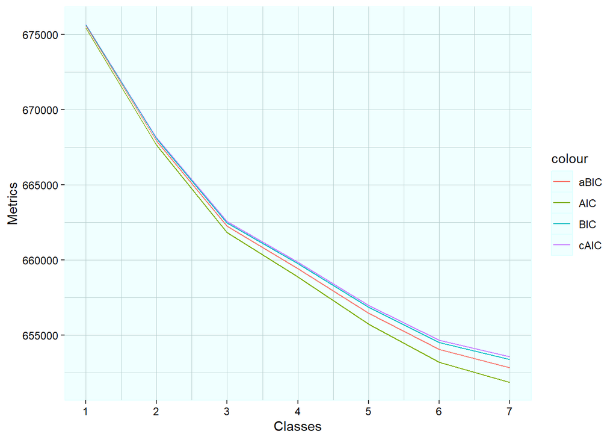

```r
screeplot <- ggplot(class.table, aes(Classes)) +
    scale_x_continuous(breaks = seq(0, 12, by = 1))+
    geom_line(aes(y = AIC, colour = "AIC")) +
  geom_line(aes(y = CAIC, colour = "cAIC")) +
    geom_line(aes(y = BIC, colour = "BIC")) +
  geom_line(aes(y = ABIC, colour = "aBIC")) +labs(y = "Metrics") + ggtitle(NULL)+



  theme(panel.background = element_rect(fill = "#F0FFFF", colour = "#E0FFFF",
             size = 0.5, linetype = "solid"),
  panel.grid = element_line(size = 0.25, linetype = 'solid',
                                colour = "#B4CDCD"),
  axis.text = element_text(colour = "black"),
  axis.title = element_text(colour = "black"))

print(screeplot)
```

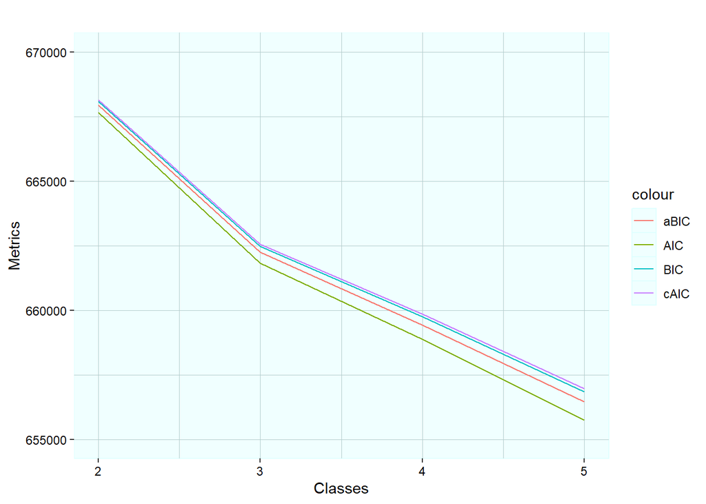

```r
screeplot <- ggplot(class.table, aes(Classes)) +
    geom_line(aes(y = AIC, colour = "AIC")) +
  geom_line(aes(y = CAIC, colour = "cAIC")) +
    geom_line(aes(y = BIC, colour = "BIC")) +
  geom_line(aes(y = ABIC, colour = "aBIC")) +
    scale_x_continuous(breaks = seq(0, 12, by = 1)) +
    labs(y = "Metrics") + ggtitle(" ") +
  xlim(2, 5) + ylim(655000, 670000)+

    theme(panel.background = element_rect(fill = "#F0FFFF", colour = "#E0FFFF",
             size = 0.5, linetype = "solid"),
  panel.grid = element_line(size = 0.25, linetype = 'solid',
                                colour = "#B4CDCD"),
  axis.text = element_text(colour = "black"),
  axis.title = element_text(colour = "black"))
print(screeplot)
```

Now, we will select the best model provided by the analysis and view the names of the final identified classes. You can compare the different solutions using BIC or AIC information criteria. BIC is preferred over AIC for latent class models, though both are generally used. A lower BIC value is better than a higher one. Along with AIC and BIC, you also obtain a Chi-square goodness-of-fit measure.

AIC does not correct for sample size, which can be quite problematic with larger samples. (See cAIC and aBIC below.)

Follow the instructions below. Select the best model by examining the scree plot and the model estimation results one by one. The best model should have a number of classes falling between the “elbow” shown in the scree plot and the model with the lowest BIC. Check for trivial classes in the candidate models—starting with the model that has the lowest BIC—by typing `myresult[[i]]`. Trivial classes are those with estimated or predicted class population percentages below 2%. For example, if the elbow is at 3 and the lowest BIC is at 5, check the class population percentages for model 5 by typing `myresult[[5]]`. If there is no trivial class, then model 5 is the best choice. If there is one or more trivial classes, check the next model (with 4 classes) by typing `myresult[[4]]`. Characterize each class.

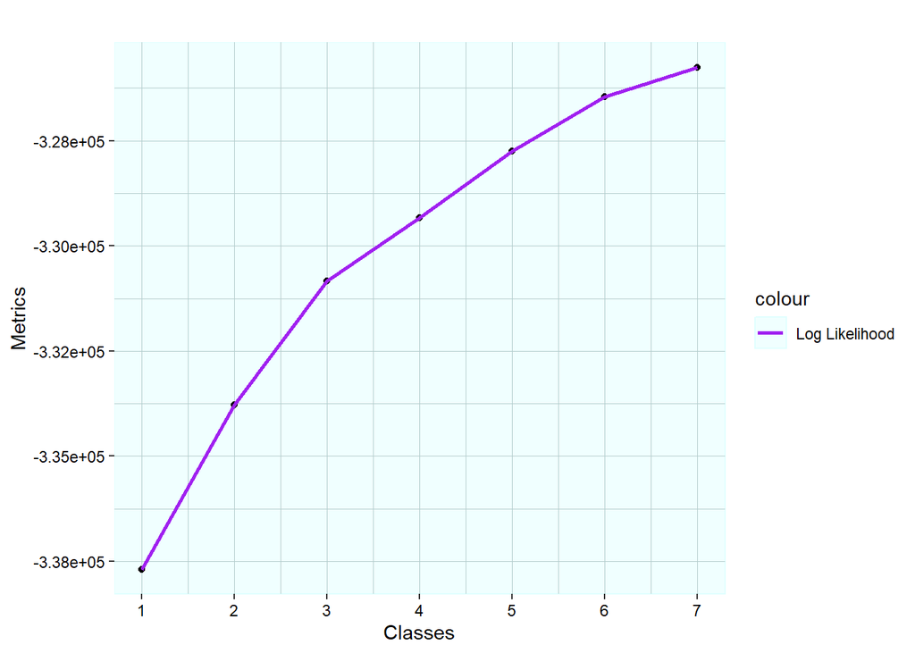

```r
# screeplot <- ggplot(results, aes(c(1:nrow(results)))) +
#      geom_line(aes(y = log_likelihood, colour = "Log likelihood")) +
#      scale_x_continuous(breaks = seq(0, 12, by = 1)) +
#      labs(y = "Metrics", x='Classes') + ggtitle(" ")

library(scales)
screeplot <- ggplot(class.table,aes(y=llik,x=Classes)) +
    geom_point() + scale_x_continuous(breaks = seq(0, 12, by = 1)) +
    geom_line(aes(y = llik, colour = "Log Likelihood"), linewidth=1)+
    scale_y_continuous(labels = scientific) +
    scale_colour_manual(values=c("purple"))+
    labs(y = "Metrics") + ggtitle(" ")+

    theme(panel.background = element_rect(fill = "#F0FFFF", colour = "#E0FFFF",
             size = 0.5, linetype = "solid"),
  panel.grid = element_line(size = 0.25, linetype = 'solid',
                                colour = "#B4CDCD"),
  axis.text = element_text(colour = "black"),
  axis.title = element_text(colour = "black"))


screeplot1 <- ggplot(class.table,aes(y=residualdf,x=Classes)) +
    geom_point() + scale_x_continuous(breaks = seq(0, 12, by = 1)) +
geom_line(aes(y = residualdf, colour = "Residual degrees of freedom"), linewidth=1)+
    scale_y_continuous(labels = scientific) +
    scale_colour_manual(values=c("blue"))+
    labs(y = "Metrics") + ggtitle(" ")+

    theme(panel.background = element_rect(fill = "#F0FFFF", colour = "#E0FFFF",
             size = 0.5, linetype = "solid"),
  panel.grid = element_line(size = 0.25, linetype = 'solid',
                                colour = "#B4CDCD"),
  axis.text = element_text(colour = "black"),
  axis.title = element_text(colour = "black"))



screeplot3 <- ggplot(class.table,aes(y=likelihood_ratio,x=Classes)) +
  geom_point() + scale_x_continuous(breaks = seq(0, 12, by = 1)) +
  geom_line(aes(y = likelihood_ratio, colour = "Likelihood ratio"), linewidth=1)+
    scale_colour_manual(values=c("pink"))+
  scale_y_continuous(labels = scientific) +
  labs(y = "Metrics") + ggtitle(" ")+

    theme(panel.background = element_rect(fill = "#F0FFFF", colour = "#E0FFFF",
             size = 0.5, linetype = "solid"),
  panel.grid = element_line(size = 0.25, linetype = 'solid',
                                colour = "#B4CDCD"),
  axis.text = element_text(colour = "black"),
  axis.title = element_text(colour = "black"))


print(screeplot)
```

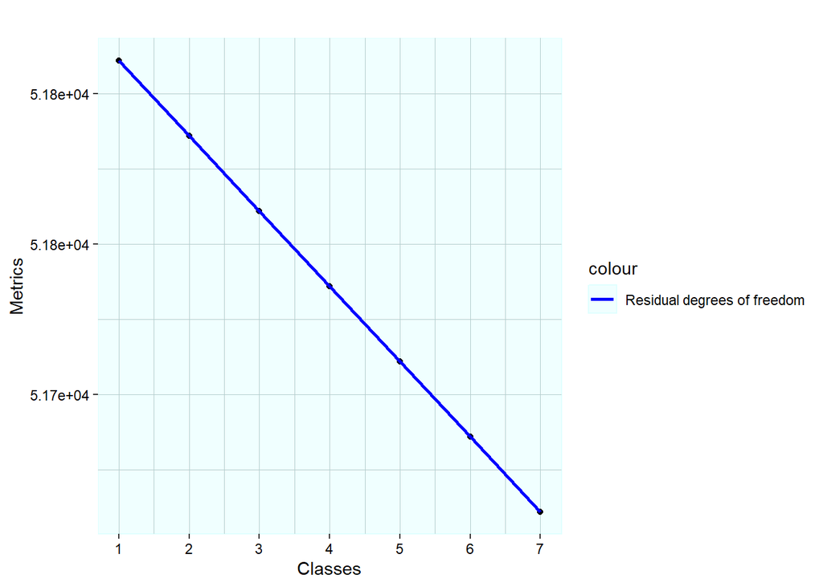

```r
print(screeplot1)
```

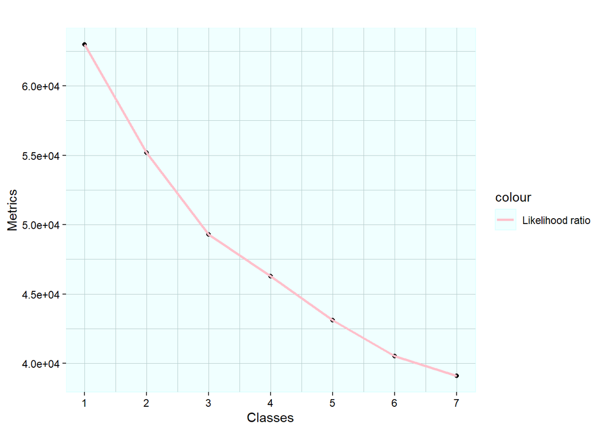

```r
print(screeplot3)
```

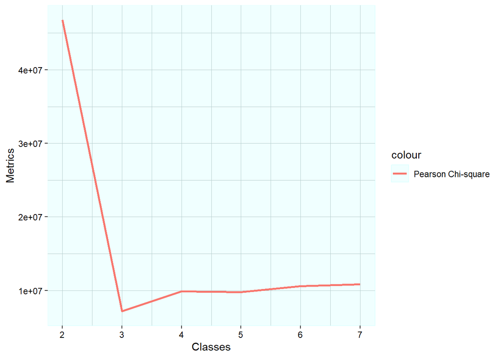

```r
screeplot2 <- ggplot(class.table[-1,], aes(Classes)) +
  geom_line(aes(y = Chisq, colour = "Pearson Chi-square"), linewidth=1) +
  scale_y_continuous(labels = scientific)+
                     # breaks=c(9000000, 10000000, 100000000, 110000000, 111000000, 111400000),

  scale_x_continuous(breaks = seq(1, 7, by = 1)) +
  labs(y = "Metrics") + ggtitle(NULL)+

    theme(panel.background = element_rect(fill = "#F0FFFF", colour = "#E0FFFF",
             size = 0.5, linetype = "solid"),
  panel.grid = element_line(size = 0.25, linetype = 'solid',
                                colour = "#B4CDCD"),
  axis.text = element_text(colour = "black"),
  axis.title = element_text(colour = "black"))

print(screeplot2)
```

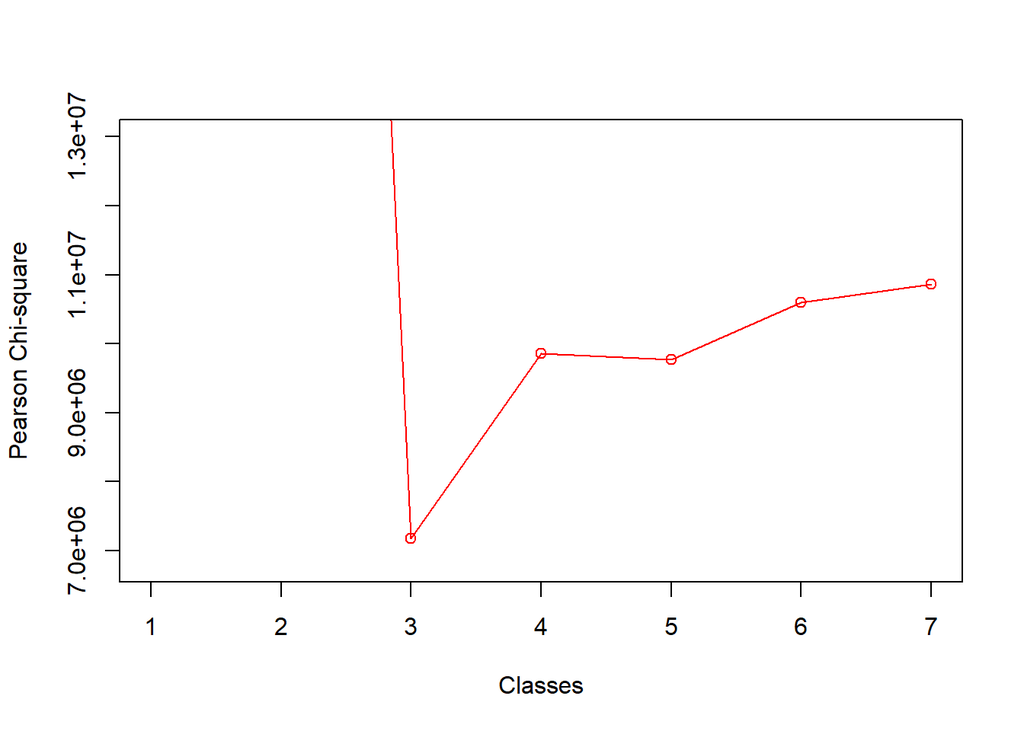

```r
plot(x = 1:J, y=class.table$Chisq, ylim = c(6800000, 13000000), type = 'o', xlab = 'Classes', ylab='Pearson Chi-square', col='red')
```

A higher log-likelihood indicates a better model fit (unlike standard likelihood). `llik`: The maximum log-likelihood value of the estimated model.

Caution is required if the degrees of freedom are negative. According to the documentation by Lanza et al. (http://www.methodology.psu.edu/ra/lca/model-faq/), a model yields negative degrees of freedom when it attempts to estimate more parameters than is feasible. If you encounter negative degrees of freedom, reduce the number of latent classes or latent states, or impose parameter constraints to lower the number of parameters being estimated.

Avoid using AIC for LCA, as it performs poorly; instead, use cAIC, BIC, and aBIC. Lower values for these indices indicate a better fit.

Pearson’s chi-square goodness-of-fit statistic for fitted versus observed multi-way tables. The goodness of fit of a specific latent class model to the observed data can be assessed using a chi-square test based on observed and expected frequencies. This test checks for independence between latent class membership and class membership. A drawback in our case is that the null hypothesis is highly likely to be rejected due to the large sample size.

```r
##
results <- data.frame(Modell=c("Model 4"),
                      log_likelihood=myresult[[4]]$llik,
                      df = myresult[[4]]$resid.df,
                      BIC=myresult[[4]]$bic,
                      AIC=myresult[[4]]$aic,
                      ABIC=  (-2*myresult[[4]]$llik) + ((log((myresult[[4]]$N + 2)/24)) * myresult[[4]]$npar),
                      CAIC = (-2*myresult[[4]]$llik) + myresult[[4]]$npar * (1 + log(myresult[[4]]$N)),
                      likelihood_ratio=myresult[[4]]$Gsq)
```

```r
results$Modell<-as.integer(results$Modell)
results=results

for (i in 1:J) {results[i,1]<-paste('Model', i)}



for (i in 2:J) {

  results[i,2]<-myresult[[i]]$llik
  results[i,3]<-myresult[[i]]$resid.df
  results[i,4]<-myresult[[i]]$bic
  results[i,5]<-myresult[[i]]$aic
  results[i,6]<-(-2*myresult[[i]]$llik) + ((log((myresult[[i]]$N + 2)/24)) * myresult[[i]]$npar) #abic
  results[i,7]<- (-2*myresult[[i]]$llik) + myresult[[i]]$npar * (1 + log(myresult[[i]]$N)) #caic
  results[i,8]<-myresult[[i]]$Gsq

}

print(results)
```

```
##    Modell log_likelihood    df      BIC      AIC     ABIC     CAIC
## 1 Model 1      -329334.4 51736 659743.5 658866.8 659428.9 659842.5
## 2 Model 2      -333777.4 51786 668086.7 667652.8 667931.0 668135.7
## 3 Model 3      -330835.2 51761 662473.8 661818.4 662238.6 662547.8
## 4 Model 4      -329334.4 51736 659743.5 658866.8 659428.9 659842.5
## 5 Model 5      -327749.2 51711 656844.6 655746.5 656450.5 656968.6
## 6 Model 6      -326454.9 51686 654527.3 653207.8 654053.8 654676.3
## 7 Model 7      -325751.5 51661 653391.9 651851.0 652838.9 653565.9
##   likelihood_ratio
## 1         46286.03
## 2         55172.01
## 3         49287.66
## 4         46286.03
## 5         43115.70
## 6         40526.99
## 7         39120.19
```

```r
ztable::ztable(results)
```

[output not shown]

[output cut: 47 more lines]

[output not shown]

There are statistics, such as the log-likelihood value, that indicate the goodness of fit of a model. The higher the log-likelihood value, the better the model fits the dataset.

Regarding the Bayesian Information Criterion (BIC), we prefer models with lower values. Similarly, lower AIC values indicate a model that fits the data better.

```r
save.image("fullresultLCA3.RData")
```

There is a critical step: we select the number of classes we want, based on the previous results:

```r
# If the best model is the 2-class model
# !Note: Please change the "classnumber" object according to your own results

classnumber <- 3
```

```r
myMMcondition$class <- myresult[[classnumber]]$predclass
myMMcondition$class4 <- myresult[[4]]$predclass
```

We convert the disease variables into numeric variables by creating a new DataFrame using the following function.

```r
cris<-as.data.frame(sapply(myMMcondition[, 2:(ncol(myMMcondition))], as.numeric))
# chronic diseases

labels <- colnames(cris)
labels=labels[! labels %in% c('class', 'class3', 'class4')]

codigos <- cris %>% names()
codigos=codigos[! codigos %in% c('class', 'class3', 'class4')]
MM.condition <- codigos
base_relacional <- data.frame(condition = codigos,label = labels)
```

Next, we will (optionally) create a graph showing the estimated conditional response probabilities for each class.

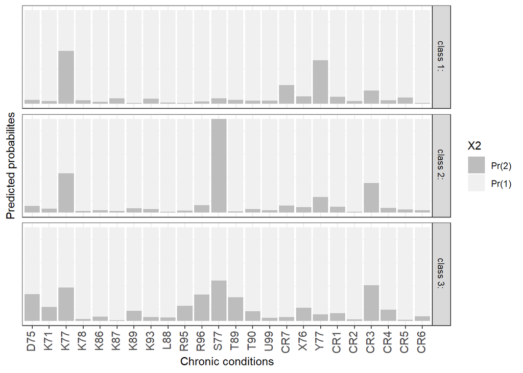

```r
# Plot
library(ggplot2)

classprob <- reshape::melt(myresult[[classnumber]]$probs, level = 2)
prob.fig <- ggplot(classprob, aes(x = L2, y = value, fill = X2))
prob.fig <- prob.fig + geom_bar(stat = "identity", position = "stack")
prob.fig <- prob.fig + facet_grid(X1 ~ .)
prob.fig <- prob.fig + scale_fill_brewer(type = "seq", palette ="Greys") +theme_bw()
prob.fig <- prob.fig + labs(x = "Chronic conditions",y = "Predicted probabilites", fill = "X2")
prob.fig <- prob.fig + theme(axis.text.y = element_blank(),
                             axis.ticks.y=element_blank(),
                             panel.grid.major.y=element_blank(),
                             )
prob.fig <- prob.fig + scale_x_discrete(labels = labels)
prob.fig <- prob.fig + theme(axis.text.x = element_text(angle = 90, vjust = 0.3, hjust = 1, size = 11))
prob.fig <- prob.fig + guides(fill = guide_legend(reverse = TRUE))
print(prob.fig)
```

In the following object, we need to replace the number inside the double brackets with the model number (which is the same as the class number).

```r
myMMsample.predclass4 <- cbind(myMMsample, "LC_2prev_4class" = myresult[[4]]$predclass) # CAMBIAR SEGÚN EL NÚMERO DE CLÚSTERS
#write.dta(myMMsample.predclass5, "5 classes 2 prevalence.dta")
#unspecific is cluster 3
```

```r
#write.table(char.freq2, file = "Comparing 10 models.txt", quote = FALSE, row.names = F)

cris<-as.data.frame(sapply(myMMcondition[, 2:(ncol(myMMcondition))], as.numeric))
# or cris<-as.data.frame(sapply(myMMcondition, as.numeric))


# Name classes by identifying conditions that uniquely characterize the class
my.overall.prev <- apply(cris, 2, mean)
my.overall.sum <- apply(cris[, MM.condition], 2, sum)

myprev <- OEratio <-  mysum<- exclusivity <- myName_a <- myName_b <-
  character1 <- character2 <- char.freq1 <- char.freq2 <- vector("list",classnumber)

cris$class3=NULL
cris$class=myresult[[3]]$predclass
cris$class4 <- myresult[[4]]$predclass
cris$class5 <- myresult[[5]]$predclass
```

```r
myprev_old <- OEratio_old <-  mysum_old<- exclusivity_old <- myName_a_old <- myName_b_old <- character1_old <- character2_old <- char.freq1_old <- char.freq2_old <- vector("list",classnumber)

for (i in 1:classnumber){
  myprev_old[[i]] <- apply(myMMcondition[which(myMMcondition$class == i), MM.condition], 2, mean)
  OEratio_old[[i]] <- which(myprev_old[[i]]/my.overall.prev[MM.condition] >= 2)
  mysum_old[[i]] <- apply(myMMcondition[which(myMMcondition$class == i), MM.condition], 2, sum)
  exclusivity_old[[i]] <- which(mysum_old[[i]]/my.overall.sum >= 0.25)
  myName_a_old[[i]] <- base_relacional[base_relacional$condition %in% MM.condition[OEratio_old[[i]]],]
  myName_b_old[[i]] <- base_relacional[base_relacional$condition %in% MM.condition[exclusivity_old[[i]]],]
  character1_old[[i]] <- union(myName_a_old[[i]], myName_b_old[[i]])
  character2_old[[i]] <- intersect(myName_a_old[[i]], myName_b_old[[i]])
  char.freq1_old[[i]]<- cbind(union(myName_a_old[[i]], myName_b_old[[i]]), myprev_old[[i]][character1_old[[i]]$condition])
  char.freq2_old[[i]]<- cbind(intersect(myName_a_old[[i]], myName_b_old[[i]]), myprev_old[[i]][character2_old[[i]]$condition])
}
```

Below, we implement a loop similar to the one in the primary `LCA_common_synthax_FINAL` script (the code immediately preceding this) to create `character1`, `character2`, `char.freq1`, and `char.freq2`. These objects help us distinguish between diseases within each cluster. Uses:

- `char.freq1`: Created to determine if a variable is associated with a given cluster. It applies the criterion that a disease within a cluster must have an Observed/Expected (O/E) prevalence ratio of 2 or higher, and/or a cluster exclusivity of 25% or higher. This is generally the appropriate approach, as the authors specify that meeting either one of the two criteria suffices. It is a less restrictive criterion, since a disease is included in the cluster if it meets just one of the two conditions.
- `char.freq2`: Similarly used to assess the relationship between a variable and the cluster, but in this case, the requirement is that diseases must meet *both* criteria rather than just one. Thus, they must have an O/E ratio ≥ 2 and exclusivity ≥ 25%. We calculate this as well.

Of course, other criteria may be used, or the values of 2 and 25% can be modified in the code that follows.

```r
myName_a_cris=list()
myName_b_cris=list()
character1_cris=list()
character2_cris=list()
list_final=list()

'%!in%' <- function(x,y)!('%in%'(x,y))

library('sjmisc')

for (i in 1:classnumber){
  myprev[[i]] <- apply(cris[which(cris$class == i), MM.condition], 2, mean)
  # prevalencia de las enfermedades dentro de cada clúster

  OEratio[[i]] <- which(myprev[[i]]/my.overall.prev[MM.condition] >= 2)
  # O/E ratio mayor o igual al 2%

  # probando con >1
  mysum[[i]] <- apply(cris[which(cris$class == i), MM.condition], 2, sum)

  exclusivity[[i]] <- which(mysum[[i]]/my.overall.sum >= 0.25) # exclusividad mayor al 25%


  names_OEratio=names(OEratio[[i]])
  if(length(names_OEratio)!=1){myName_a_cris[[i]] <- cris[ , which(names(cris) %in% names_OEratio)]}
  # data frame con solamente aquellas variables con un O/E ratio >= 2
  if(length(names_OEratio)==1){
    myName_a_cris[[i]] <-data.frame( cris[ , which(names(cris) %in% names_OEratio)])
    colnames(myName_a_cris[[i]])=names_OEratio}


  names_exclusivity=names(exclusivity[[i]])
  myName_b_cris[[i]] <- cris[ , which(names(cris) %in% names_exclusivity)]
  # data frame con
  # solamente aquellas variables con una exclusividad >= 25%
  if (class(myName_b_cris[[i]])=='numeric') { # o sea hay solo 1 enfermedad
     myName_b_cris[[i]] <- as.data.frame(cris[ , which(names(cris) %in% names_exclusivity)])
     names(myName_b_cris[[i]])=colnames(cris)[which(names(cris) %in% names_exclusivity)]
  }



  if (is_empty(names(myName_a_cris[[i]]))) {
    character1[[i]] <- myName_b_cris[[i]][1:nrow(myName_a_cris[[i]]),]
  } else{
  character1[[i]] <- cris[sort(unique(c(names(myName_a_cris[[i]]), names(myName_b_cris[[i]]))))][1:nrow(myName_a_cris[[i]]),] # UNION.
  # columnas repetidas y no repetidas. Igual que list_final del siguiente bucle

  if (class(character1[[i]])=='numeric') { # o sea hay solo 1 enfermedad
     character1[[i]] <- as.data.frame(cris[sort(unique(c(names(myName_a_cris[[i]]), names(myName_b_cris[[i]]))))][1:nrow(myName_a_cris[[i]]),])
     names(character1[[i]])=sort(unique(c(names(myName_a_cris[[i]]), names(myName_b_cris[[i]]))))
  }

  }
  char.freq1[[i]]<- myprev[[i]][colnames(character1[[i]])]

  # haremos una intersección de columnas, es decir,
  # haremos un df con las columnas en común de a y b

  for(x in 1:ncol(myName_a_cris[[i]])){

    if(any(colnames(myName_b_cris[[i]])==colnames(myName_a_cris[[i]])[x]) &
       !is.na(any(colnames(myName_b_cris[[i]])==
                  colnames(myName_a_cris[[i]])[x]))){ # y no es NA
      # si alguna columna de a la tiene repetida b (se llaman igual)

      teemp= which(colnames(myName_a_cris[[i]]) %in% colnames(myName_b_cris[[i]]))
      # posiciones de nº columna de a que está repetida en b

      asd=myName_a_cris[[i]][,teemp]

      if(is.data.frame(asd)){character2[[i]] <- asd}
      else{
        df_teemp=data.frame(asd)
        colnames(df_teemp)=colnames(myName_a_cris[[i]])[teemp]
        character2[[i]] <- df_teemp
        char.freq2[[i]]<-  myprev[[i]][colnames(character2[[i]])]
      }}}




  temp_a=myName_a_cris[[i]] # data frame según O/E ratios
  temp_b=myName_b_cris[[i]] # data frame según exlusividad
  if (length(names(temp_a))>length(names(temp_b)) | length(names(temp_a))==length(names(temp_b))){
    # si el numero de columnas de ambos data frame es igual
    # o el de a es mayor

    if(!identical(temp_b, temp_a)){ # si temp_a no es idéntico a temp_b

      df_final=temp_a # con todas las variables de a

      e=which(colnames(temp_b) %!in% colnames(temp_a))
      # numeros de columna de b que no están en a, si los hay

      if(!length(e)==0){df_final=cbind(df_final, temp_b[,e])}
        # si e no es 0, sino que hay columnas de b
        # que no posee a, añadir esas columnas de b

      list_final[[i]]=df_final}


    else{ # si son idénticos, añadir al df final
      # alguno de a o b (indiferente)
      df_final=temp_a
      list_final[[i]]=df_final
    }}



  if (length(names(temp_b))>length(names(temp_a))){
    # si temp_b tiene más columnas

    if(!identical(temp_a, temp_b)){ # si temp_a no es idéntico a temp_b
      df_final=temp_b # todas las variables de b

      e=which(colnames(temp_a) %!in% colnames(temp_b))
      # numeros de columna de a que no están en b, si los hay

      if(!length(e)==0){df_final=cbind(df_final, temp_a[,e])}
        # si e no es 0, sino que hay columnas de b
        # que no posee a, añadir esas columnas de b

      list_final[[i]]=df_final}


    else{
      df_final=temp_a
      list_final[[i]]=df_final}}}
```

The save.image() command saves an object with the result (optional), and exports a database with write.dta (optional)

```r
# Print class names
#head(char.freq1) # If use both O/E ratio > 2 and exclusivity > 25%
#head(char.freq2) # If use either O/E ratio > 2 and exclusivity > 25%)
```

```r
#identify which class was each lopnr assigned to

head(myresult[[4]]$predclass)
```

```
## [1] 1 3 3 3 4 2
```

```r
myMMsample.predclass4 <- cbind(myMMsample, "LC_2prev_4class" = myresult[[4]]$predclass)

#unspecific is cluster 3

head(myresult[[5]]$predclass)
```

```
## [1] 2 1 1 1 5 4
```

```r
myMMsample.predclass5 <- cbind(myMMsample, "LC_2prev_5class" = myresult[[5]]$predclass) # CAMBIAR PARA OTRA CANTIDAD DE CLÚSTER
# write.dta(myMMsample.predclass5, "5 classes 1.5 prevalence.dta")
#unspecific cluster is #1


# write.table(char.freq2, file = "Comparing 10 models.txt", quote = FALSE, row.names = F)
```

We will order the variables by the probabilities within each class.

```r
df_4clase=as.data.frame(myresult[[classnumber]][["probs"]])
df_4clase=df_4clase[,endsWith(colnames(df_4clase), 'Pr.2.')] # probabilidad de SI/2, no 1/Ausencia enfermedad
colnames(df_4clase)=substr(colnames(df_4clase), 1, 3)
df_4clase <- data.frame(t(df_4clase[,])) # tercera columna, la de la clase 3
colnames(df_4clase)=paste("C", 1:classnumber, sep="")


df_1clase=df_4clase[order(df_4clase$C1, decreasing = TRUE), ]
df_2clase=df_4clase[order(df_4clase$C2, decreasing = TRUE), ]
df_3clase=df_4clase[order(df_4clase$C3, decreasing = TRUE), ]
```

We rank them according to the probability of the disease within each class.

```r
imprimir_C1=list('ch1'=intersect(rownames(df_1clase), colnames(character1[[1]])), 'ch2'=intersect(rownames(df_1clase), colnames(character2[[1]])))
imprimir_C2=list('ch1'=intersect(rownames(df_2clase), colnames(character1[[2]])), 'ch2'=intersect(rownames(df_2clase), colnames(character2[[2]])))
imprimir_C3=list('ch1'=intersect(rownames(df_3clase), colnames(character1[[3]])), 'ch2'=intersect(rownames(df_3clase), colnames(character2[[3]])))
```

Now, we will replace the names in our data frame with the actual disease names. The code below applies specifically to the variables in our current data frame; for any other dataset, the variables must be coded correctly. For instance, if our initial dataset contains a column named “Enfermedad1” that actually corresponds to “Asthenia/fatigue/weakness,” we would code it as follows: `h[h=='Enfermedad1'] <- 'Asthenia/fatigue/weakness'`. We would then repeat this process for all the diseases in our dataset.

I am changing the names of the diseases:

```r
CIAP_BDCAP=rbind(CIAP_BDCAP, c('CR1', 'Cardiopatías isquémicas', 'CR1'))
CIAP_BDCAP=rbind(CIAP_BDCAP, c('CR2', 'Enfermedades cerebrovasc e ictus', 'CR2'))
CIAP_BDCAP=rbind(CIAP_BDCAP, c('CR3', 'Artrosis', 'CR3'))
CIAP_BDCAP=rbind(CIAP_BDCAP, c('CR4', 'Neoplasias respiratorias', 'CR4'))
CIAP_BDCAP=rbind(CIAP_BDCAP, c('CR5', 'Neoplasias aparato urinario', 'CR5'))
CIAP_BDCAP=rbind(CIAP_BDCAP, c('CR6', 'Neoplasias genitales femeninas', 'CR6'))
CIAP_BDCAP=rbind(CIAP_BDCAP, c('U99.01', 'Insuficiencia renal crónica', 'U99.01'))
CIAP_BDCAP=rbind(CIAP_BDCAP, c('CR7', 'Insuficiencia renal crónica', 'CR7'))
```

```r
colnames(myMMsample)[2:ncol(myMMsample)] =substr(colnames(myMMsample),1,nchar(colnames(myMMsample))-6)[2:ncol(myMMsample)] # lo dejo en A79, D76...etc

nombres_CIAP=match(colnames(myMMsample[,-c(1)]), CIAP_BDCAP$CIAP2) # quito lo que no son enfermedades
colnames(myMMsample)[2:ncol(myMMsample)]=CIAP_BDCAP$`Literal CIAP2`[nombres_CIAP]
```

```r
#for (i in 1:classnumber){

#  if (!is.null(character2[[i]])){
#  g=names(character2[[i]])
# for (j in 1:length(g)){names(character2[[i]])[j]=g[j]}
```

```r
knitr::kable(imprimir_C1$ch1, caption = "Enfermedades para el clúster 1")
```

Enfermedades para el clúster 1

| x |
| --- |
| Artrosis |
| Asma |
| Artritis reumatoide |
| Neoplasia maligna mama en la mujer |
| Neoplasias genitales femeninas |
| Neoplasias malignas de colon/recto |
| Neoplasias respiratorias |
| Diabetes insulinodependiente |

```r
knitr::kable(imprimir_C2$ch1, caption = "Enfermedades para el clúster 2")
```

Enfermedades para el clúster 2

| x |
| --- |
| Hipertensión no complicada |
| Artrosis |
| Diabetes no insulinodependiente |
| Asma |
| Fibrilación/flutter auricular |
| Artritis reumatoide |
| Cardiopatías isquémicas |
| Neoplasias malignas de la piel |
| EPOC |
| Otros problemas/enfermedades urinarias |
| Insuficiencia renal crónica |
| Enfermedades cerebrovasc e ictus |
| Isquemia cerebral transitoria |
| Neoplasias malignas de colon/recto |
| Neoplasia maligna mama en la mujer |
| Embolismo pulmonar |
| Neoplasia malignas de próstata |
| Neoplasias aparato urinario |
| Neoplasias genitales femeninas |
| Neoplasias respiratorias |
| Fiebre/enf reumática cardiaca |
| Diabetes insulinodependiente |

```r
knitr::kable(imprimir_C3$ch1, caption = "Enfermedades para el clúster 3")
```

Enfermedades para el clúster 3

| x |
| --- |
| Diabetes no insulinodependiente |
| Cardiopatías isquémicas |
| Fibrilación/flutter auricular |
| Hipertensión afectación órganos diana |
| Insuficiencia cardíaca |
| Enfermedades cerebrovasc e ictus |
| EPOC |
| Otros problemas/enfermedades urinarias |
| Insuficiencia renal crónica |
| Isquemia cerebral transitoria |
| Neoplasias malignas de la piel |
| Neoplasia malignas de próstata |
| Neoplasias aparato urinario |
| Fiebre/enf reumática cardiaca |
| Embolismo pulmonar |

```r
knitr::kable(imprimir_C1$ch2, caption = "Enfermedades para el clúster 1")
```

Enfermedades para el clúster 1

| x |
| --- |
| Asma |
| Artritis reumatoide |
| Neoplasia maligna mama en la mujer |
| Neoplasias genitales femeninas |
| Diabetes insulinodependiente |

```r
knitr::kable(imprimir_C2$ch2, caption = "Enfermedades para el clúster 2")
```

Enfermedades para el clúster 2

| x |
| --- |

```r
knitr::kable(imprimir_C3$ch2, caption = "Enfermedades para el clúster 3")
```

Enfermedades para el clúster 3

| x |
| --- |
| Cardiopatías isquémicas |
| Fibrilación/flutter auricular |
| Hipertensión afectación órganos diana |
| Insuficiencia cardíaca |
| Enfermedades cerebrovasc e ictus |
| CR7 |
| Isquemia cerebral transitoria |
| Neoplasia malignas de próstata |
| Fiebre/enf reumática cardiaca |

Here we can see that the second criterion (captured in `character2`) is more restrictive.

We would like to assign a name to each cluster—purely for informational purposes—based on the diseases that comprise them.

Since various authors use prevalence to determine which diseases make up each cluster—a method that allows for easy exclusion—and given that we have calculated prevalences without yet utilizing them, I believe this is the best approach.

I will create a loop that returns an object containing the clusters and their constituent diseases. For diseases that appear in multiple classes, we will use prevalence data to decide which class they should ultimately belong to; specifically, a disease will be removed from the class where it is less prevalent. Additionally, the loop will report the prevalence of each repeated disease within each cluster, allowing us to assess whether the differences are significant (making it easy to determine the final cluster assignment) or minor (which might allow us to reassign a class to a different cluster based on medical considerations).

The following loop runs automatically; no changes are required.

```r
prueba=char.freq1

for (ele1 in 1:length(prueba)){
  quitar_vect=c()
  quitar_2vect=c()
  for (ele2 in 1:(length(prueba))){
    if (ele1==ele2) {next}
    inters=intersect(names(prueba[[ele1]]),names(prueba[[ele2]]))
    if (length(inters)>0){
      for(i in 1:length(inters)){
        matc1=match(inters[i],names(prueba[[ele1]]))
        matc2=match(inters[i],names(prueba[[ele2]]))
        if (prueba[[ele1]][matc1]>prueba[[ele2]][matc2]) {
          quitar_2vect=append(quitar_2vect, matc2)}
        else if (prueba[[ele1]][matc1]<prueba[[ele2]][matc2]) {
         quitar_vect=append(quitar_vect, matc1)}
      }



    }

  }

  if (!is.null(quitar_vect)){prueba[[ele1]]=prueba[[ele1]][-quitar_vect]}
    if (!is.null(quitar_2vect)){prueba[[ele2]]=prueba[[ele2]][-quitar_2vect]}

}
```

```r
knitr::kable(names(prueba[[1]]), caption = "Enfermedades para el clúster 1")
```

Enfermedades para el clúster 1

| x |
| --- |
| Artrosis |
| Neoplasias respiratorias |
| Neoplasias genitales femeninas |
| Neoplasias malignas de colon/recto |
| Artritis reumatoide |
| Asma |
| Diabetes insulinodependiente |
| Neoplasia maligna mama en la mujer |

```r
knitr::kable(names(prueba[[2]]), caption = "Enfermedades para el clúster 2")
```

Enfermedades para el clúster 2

| x |
| --- |
| Fibrilación/flutter auricular |
| Hipertensión no complicada |
| Isquemia cerebral transitoria |
| EPOC |
| Neoplasia malignas de próstata |
| Cardiopatías isquémicas |

```r
knitr::kable(names(prueba[[3]]), caption = "Enfermedades para el clúster 3")
```

Enfermedades para el clúster 3

| x |
| --- |
| Enfermedades cerebrovasc e ictus |
| Neoplasias aparato urinario |
| Insuficiencia renal crónica |
| Fiebre/enf reumática cardiaca |
| Insuficiencia cardíaca |
| Hipertensión afectación órganos diana |
| Embolismo pulmonar |
| Neoplasias malignas de la piel |
| Diabetes no insulinodependiente |
| Otros problemas/enfermedades urinarias |

# Tabla1 grupos

```r
DGPS_prescrip_CMBD=distinct(DGPS_prescrip_CMBD[,c(1, 6, 8:9, 12, 37, 40, 44)]) # "cipa"  codigo_atc  "Grupo_ATC"   "num_ing"  C1 "EsCovid"   "UCI"   "num"   "COVIDmortalidad"
```

```r
DGPS_prescrip_CMBD$C1[is.na(DGPS_prescrip_CMBD$C1) | (DGPS_prescrip_CMBD$C1!='U07.1' & DGPS_prescrip_CMBD$C1!='u07.1' & DGPS_prescrip_CMBD$C1!='UO7.1' & DGPS_prescrip_CMBD$C1!='Uo7.1' & DGPS_prescrip_CMBD$C1!='uo7.1' & DGPS_prescrip_CMBD$C1!='S')]='N'

DGPS_prescrip_CMBD$C1[DGPS_prescrip_CMBD$C1=='U07.1' | DGPS_prescrip_CMBD$C1=='u07.1' | DGPS_prescrip_CMBD$C1=='UO7.1' | DGPS_prescrip_CMBD$C1=='Uo7.1' | DGPS_prescrip_CMBD$C1=='uo7.1']='S'
```

```r
DGPS_prescrip_CMBD$HospitPorCOVID=DGPS_prescrip_CMBD$C1
DGPS_prescrip_CMBD$C1=NULL
```

I merge this with the CIPA and the myMMcondition

```r
base=left_join(myMMcondition[,c(1,26)], pob, by='cipa')


base=dplyr::distinct(left_join(base, DGPS_prescrip_CMBD, by='cipa'))
```

```r
2020-65 # incluido 65 años
```

```
## [1] 1955
```

```r
# '1955-01-01'
# time_length(difftime(as.Date("2020-01-01"), as.Date(hosp_UCI_muert$fec_nacimiento_pob)), "years")
base$edad=floor(time_length(difftime(as.Date("2020-07-02"), as.Date(base$fec_nacimiento_pob)), "years"))
```

Voy a hacer un bucle para dejar la base bien. No estan igual el covido, grupo, num ingreso y es covid

```r
base[is.na(base)] = "N"

base$codigo_atc[base$codigo_atc=='N'] = "Sin prescripciones previas"
base$codigo_atc[base$codigo_atc=='N'] = "Sin prescripciones previas"
base$Grupo_ATC[base$Grupo_ATC=='N'] = "Sin prescripciones previas"
base$num_ing[base$num_ing=='N'] = "No es ingreso"
```

```r
base= distinct(base)

w=as.data.frame(table(base$cipa)) # para pillar los repetidos
w=w[w$Freq>1,] # los repetidos
w$Var1=as.numeric(as.character(w$Var1)) # es factor, paso a numeric

library(stringr)

for (cipaa in sort(w$Var1)) {
  if(any(base$codigo_atc[base$cipa==cipaa]!= "Sin prescripciones previas")){

    #base$codigo_atc[base$cipa==cipaa][base$codigo_atc[base$cipa==cipaa]!= "Sin prescripciones previas"]
    base$codigo_atc[base$cipa==cipaa]=
      rep(paste(sort(unique(unlist(str_split(base$codigo_atc[base$cipa==cipaa][base$codigo_atc[base$cipa==cipaa]!= "Sin prescripciones previas"], "\\|")))), collapse = '|'),
          length(base$codigo_atc[base$cipa==cipaa]))
  }
  else {base$codigo_atc[base$cipa==cipaa]= "Sin prescripciones previas"}


  if(any(base$Grupo_ATC[base$cipa==cipaa]!= "Sin prescripciones previas")){

    base$Grupo_ATC[base$cipa==cipaa]=
      rep(paste(sort(unique(unlist(str_split(base$Grupo_ATC[base$cipa==cipaa][base$Grupo_ATC[base$cipa==cipaa]!= "Sin prescripciones previas"], ",")))), collapse = '|'),
          length(base$Grupo_ATC[base$cipa==cipaa]))
  }
  else {base$Grupo_ATC[base$cipa==cipaa]= "Sin prescripciones previas"}


  if(any(base$num_ing[base$cipa==cipaa]!= "No es ingreso")){

    base$num_ing[base$cipa==cipaa]=
      rep(paste(sort(unique(base$num_ing[base$cipa==cipaa][base$num_ing[base$cipa==cipaa]!= "No es ingreso"]))), length(base$num_ing[base$cipa==cipaa]))
  }
  else {base$num_ing[base$cipa==cipaa]= "No es ingreso"}



  if(any(base$EsCovid[base$cipa==cipaa]== "S")){

    base$EsCovid[base$cipa==cipaa]='S'
  }
  else {base$EsCovid[base$cipa==cipaa]='N'}


  if(any(base$HospitPorCOVID[base$cipa==cipaa]== "S")){

    base$HospitPorCOVID[base$cipa==cipaa]='S'
  }
  else {base$HospitPorCOVID[base$cipa==cipaa]='N'}



  if(any(base$COVIDmortalidad[base$cipa==cipaa]!= "0")){

    base$COVIDmortalidad[base$cipa==cipaa]=
      rep(paste(sort(unique(base$COVIDmortalidad[base$cipa==cipaa][base$COVIDmortalidad[base$cipa==cipaa]!= "0"])), collapse = '|'),
          length(base$COVIDmortalidad[base$cipa==cipaa]))
  }
  else {base$COVIDmortalidad[base$cipa==cipaa]='0'}
}


base=base %>% arrange(cipa) %>% distinct()
```

```r
base$EsCovid[base$EsCovid=='No es ingreso' ]='N'

base$num_ing[base$num_ing=='No es ingreso' ]='0'
base$num_ing=as.numeric(base$num_ing)

base$HospitPorCOVID[base$HospitPorCOVID=='0' ]='N'



base$UCI[base$UCI=='No es ingreso']='N'
```

```r
base$ATC_dist=rep('0', nrow(base))


for (cipaa in base$cipa) {
  if (any(base$codigo_atc[base$cipa==cipaa]!='Sin prescripciones previas')) {
    if (nrow(base[base$cipa==cipaa & base$codigo_atc!='Sin prescripciones previas',])==1) {
      base$ATC_dist[base$cipa==cipaa]=length(unlist(str_split(base$codigo_atc[base$cipa==cipaa], "\\|")))
    }
    else  {base$ATC_dist[base$cipa==cipaa]=rep(length(unlist(str_split(base$codigo_atc[base$cipa==cipaa], "\\|"))[!unlist(str_split(base$codigo_atc[base$cipa==cipaa], "\\|")) %in% 'Sin prescripciones previas']), nrow(base[base$cipa==cipaa,]))}
  }
}
```

```r
base$COVIDmortalidad[base$COVIDmortalidad=='MencionCOVID|No']='MencionCOVID'
base$COVIDmortalidad[base$COVIDmortalidad=='No|U071']='U071'
base$COVIDmortalidad[base$COVIDmortalidad=='No|U072']='U072'
```

I will compute the number of diseases

```r
myMMsample$num_enf=rowSums(myMMsample[,c(43:85)])
```

```r
base=left_join(base, myMMsample[,c(1, ncol(myMMsample))], by='cipa')
base$class.x=base$class=NULL
base=left_join(base, myMMcondition[,c('cipa', 'class', "class4")], by='cipa')
```

```r
base$ATC_dist=as.numeric(base$ATC_dist)
base$class4=as.factor(base$class4)
```

We finally make the table 1

```r
library(table1)
pvalue <- function(x, ...) {
  x <- x[-length(x)] # Remove "overall" group
y <- unlist(x)
g <- factor(rep(1:length(x), times=sapply(x, length)))
if (is.numeric(y) && (is.character(x)| is.factor(x))) { # yo
# For numeric variables, perform a standard 2-sample t-test
p <- t.test(y~g)$p.value
} else if (is.numeric(y) && (is.numeric(x))){ # yo
p <- t.test(y, g)$p.value
}else {
# For categorical variables, perform a chi-squared test of independence
p <- chisq.test(table(y, g))$p.value
}
c("", sub("<", "&lt;", format.pval(p, digits=3, eps=0.001)))
}
```

```r
base$fec_nacimiento_pob=NULL
colnames(base)
```

```
##  [1] "cipa"            "sexo_pob"        "Pais"            "codigo_atc"
##  [5] "Grupo_ATC"       "num_ing"         "EsCovid"         "UCI"
##  [9] "COVIDmortalidad" "HospitPorCOVID"  "edad"            "ATC_dist"
## [13] "num_enf"         "class"           "class4"
```

```r
table1::table1(~ . | as.factor(base$class), data=base[,c(3, 6:ncol(base))],
    render.missing=NULL, render.categorical="FREQ (PCTnoNA%)",
    extra.col=list(`Valor-p`=pvalue), extra.col.pos=5)
```

|  | 1 (N=12202) | 2 (N=38393) | 3 (N=14481) | Overall (N=65076) | Valor-p |
| --- | --- | --- | --- | --- | --- |
| Pais |  |  |  |  |  |
| ALEMANIA | 31 (0.3%) | 55 (0.1%) | 8 (0.1%) | 94 (0.1%) | <0.001 |
| ANGOLA | 1 (0.0%) | 2 (0.0%) | 0 (0%) | 3 (0.0%) |  |
| ARGELIA | 1 (0.0%) | 4 (0.0%) | 3 (0.0%) | 8 (0.0%) |  |
| ARGENTINA | 49 (0.4%) | 144 (0.4%) | 45 (0.3%) | 238 (0.4%) |  |
| ARMENIA | 1 (0.0%) | 7 (0.0%) | 3 (0.0%) | 11 (0.0%) |  |
| AUSTRALIA | 5 (0.0%) | 3 (0.0%) | 0 (0%) | 8 (0.0%) |  |
| AUSTRIA | 2 (0.0%) | 1 (0.0%) | 0 (0%) | 3 (0.0%) |  |
| BANGLADESH | 6 (0.0%) | 14 (0.0%) | 7 (0.0%) | 27 (0.0%) |  |
| BÉLGICA | 3 (0.0%) | 9 (0.0%) | 1 (0.0%) | 13 (0.0%) |  |
| BOLIVIA | 93 (0.8%) | 113 (0.3%) | 25 (0.2%) | 231 (0.4%) |  |
| BRASIL | 19 (0.2%) | 51 (0.1%) | 7 (0.0%) | 77 (0.1%) |  |
| BULGARIA | 16 (0.1%) | 80 (0.2%) | 13 (0.1%) | 109 (0.2%) |  |
| CABO VERDE | 2 (0.0%) | 4 (0.0%) | 1 (0.0%) | 7 (0.0%) |  |
| CANADÁ | 3 (0.0%) | 2 (0.0%) | 1 (0.0%) | 6 (0.0%) |  |
| CHILE | 22 (0.2%) | 59 (0.2%) | 25 (0.2%) | 106 (0.2%) |  |
| COLOMBIA | 226 (1.9%) | 438 (1.1%) | 123 (0.8%) | 787 (1.2%) |  |
| COSTA RICA | 1 (0.0%) | 0 (0%) | 0 (0%) | 1 (0.0%) |  |
| CUBA | 37 (0.3%) | 156 (0.4%) | 47 (0.3%) | 240 (0.4%) |  |
| DINAMARCA | 1 (0.0%) | 2 (0.0%) | 2 (0.0%) | 5 (0.0%) |  |
| DOMINICANA, REPÚBLICA | 77 (0.6%) | 384 (1.0%) | 56 (0.4%) | 517 (0.8%) |  |
| ECUADOR | 495 (4.1%) | 630 (1.6%) | 148 (1.0%) | 1273 (2.0%) |  |
| EGIPTO | 1 (0.0%) | 1 (0.0%) | 1 (0.0%) | 3 (0.0%) |  |
| EL SALVADOR | 5 (0.0%) | 18 (0.0%) | 6 (0.0%) | 29 (0.0%) |  |
| ESPAÑA | 10213 (83.7%) | 34178 (89.0%) | 13408 (92.6%) | 57799 (88.8%) |  |
| ESTADOS UNIDOS | 5 (0.0%) | 8 (0.0%) | 13 (0.1%) | 26 (0.0%) |  |
| FILIPINAS | 17 (0.1%) | 58 (0.2%) | 13 (0.1%) | 88 (0.1%) |  |
| FRANCIA | 50 (0.4%) | 92 (0.2%) | 21 (0.1%) | 163 (0.3%) |  |
| GUATEMALA | 3 (0.0%) | 4 (0.0%) | 4 (0.0%) | 11 (0.0%) |  |
| GUINEA | 4 (0.0%) | 17 (0.0%) | 1 (0.0%) | 22 (0.0%) |  |

[output cut: 108 more lines]